# Game Economics: Analisis de Fortnite

Diego Vallarino

2022-03-17

Los modelos de **Game Economics** estan buscando entender cómo es el comportamiento de los juegadores. Existe una gran cantidad de datos relacioandos a como juegan los diferentes millones de juegadores en el Mundo.

En este primera analisis (muy primario por cierto) he tomado algunas de las variables que componen la base de juego de Fortnite de un jugador X. En funcion de ese analisis trataremos de entender como se comporta, para ese caso especifico. Existen variables comportamentales de la persona, como variables de desempeño en el juego.

Solamente haré un pequeño analisis descritivo con cierto peso de inferencia en el mismo.

```
## tibble [87 x 16] (S3: tbl_df/tbl/data.frame)
##  $ Date                : POSIXct[1:87], format: "2018-04-10" "2018-04-10" ...
##  $ Time of Day         : POSIXct[1:87], format: "1899-12-31 18:00:00" "1899-12-31 18:00:00" ...
##  $ Placed              : num [1:87] 27 45 38 30 16 30 20 29 21 24 ...
##  $ Mental State        : chr [1:87] "sober" "sober" "high" "high" ...
##  $ Eliminations        : num [1:87] 2 1 3 1 3 0 3 2 4 1 ...
##  $ Assists             : num [1:87] 0 2 0 3 1 1 3 2 0 2 ...
##  $ Revives             : num [1:87] 0 0 0 0 1 0 0 0 1 0 ...
##  $ Accuracy            : num [1:87] 0.23 0.3 0.3 0.18 0.58 0.1 0.25 0.25 0.39 0.35 ...
##  $ Hits                : num [1:87] 14 19 32 19 42 3 41 17 50 30 ...
##  $ Head Shots          : num [1:87] 2 1 1 1 18 1 6 4 14 1 ...
##  $ Distance Traveled   : num [1:87] 271 397 608 714 1140 ...
##  $ Materials Gathered  : num [1:87] 20 123 71 244 584 ...
##  $ Materials Used      : num [1:87] 20 30 60 10 150 60 150 50 20 70 ...
##  $ Damage Taken        : num [1:87] 272 247 176 238 365 146 175 219 196 150 ...
##  $ Damage to Players   : num [1:87] 331 444 322 330 668 117 634 412 989 422 ...
##  $ Damage to Structures: num [1:87] 621 998 1109 4726 2070 ...
```

A continuacion mostramos a nivel descriptivo, cuales serian de todas las variables que se disponenen en la base, las que mejor se ajustan a explicar el modelo para tener un **Buen Desempeño** en el juego. Como vemos los pesos de las variables son positivos y negativos, pero el ajuste del modelo medido por R2, como por el Accuracy del modelo, tiene algunas debilidades en el *fit* de los valores residuales.

```
##
## Call:
## lm(formula = Placed ~ Date + Revives + Accuracy + `Head Shots` +
##     `Distance Traveled`, data = df1)
##
## Residuals:
##     Min      1Q  Median      3Q     Max
## -11.216  -5.010  -1.109   3.885  33.174
##
## Coefficients:
##                       Estimate Std. Error t value Pr(>|t|)
## (Intercept)          2.020e+04  7.158e+03   2.822  0.00600 **
## Date                -1.324e-05  4.698e-06  -2.818  0.00607 **
## Revives             -2.999e+00  1.142e+00  -2.627  0.01029 *
## Accuracy             1.362e+01  6.491e+00   2.099  0.03897 *
## `Head Shots`        -4.512e-01  1.482e-01  -3.045  0.00314 **
## `Distance Traveled` -7.861e-03  7.810e-04 -10.065 6.32e-16 ***
## ---
## Signif. codes:  0 '***' 0.001 '**' 0.01 '*' 0.05 '.' 0.1 ' ' 1
##
## s: 7.493 on 81 degrees of freedom
## Multiple R-squared: 0.694,
## Adjusted R-squared: 0.6751
## F-statistic: 36.74 on 5 and 81 DF,  p-value: < 2.2e-16
```

```
## # Accuracy of Model Predictions
##
## Accuracy: 84.93%
##       SE: 7.74%-points
##   Method: Correlation between observed and predicted
```

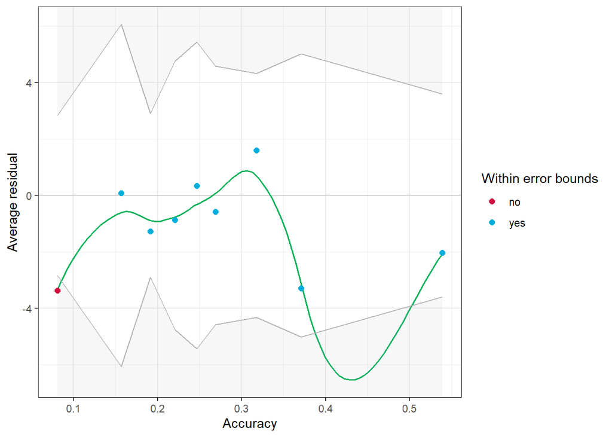

```
##
##  studentized Breusch-Pagan test
##
## data:  modelPlace
## BP = 7.0602, df = 5, p-value = 0.2162
```

```
##
##  Shapiro-Wilk normality test
##
## data:  modelPlace$residuals
## W = 0.89166, p-value = 2.452e-06
```

Para el caso del modelo de la **Eliminacion** tambien es modelo tiene una buena performance descriptivo, y por qué no inferencial, pues los valores de R2 como de Accurancy se comportan bastante bien.

```
##
## Call:
## lm(formula = Eliminations ~ Date + `Time of Day` + `Mental State` +
##     Assists + Hits + `Head Shots` + `Materials Used` + `Damage to Players` +
##     Placed, data = df)
##
## Residuals:
##      Min       1Q   Median       3Q      Max
## -1.24921 -0.43578  0.00541  0.43787  2.63679
##
## Coefficients:
##                       Estimate Std. Error t value Pr(>|t|)
## (Intercept)         -5.121e+04  1.375e+04  -3.725 0.000370 ***
## Date                -8.734e-07  5.123e-07  -1.705 0.092236 .
## `Time of Day`       -2.378e-05  6.324e-06  -3.761 0.000328 ***
## `Mental State`       1.830e-01  8.607e-02   2.126 0.036747 *
## Assists             -2.329e-01  6.096e-02  -3.820 0.000269 ***
## Hits                 2.051e-02  6.406e-03   3.201 0.001991 **
## `Head Shots`        -8.246e-02  1.924e-02  -4.285 5.23e-05 ***
## `Materials Used`     1.653e-03  4.624e-04   3.576 0.000607 ***
## `Damage to Players`  3.581e-03  4.661e-04   7.683 4.13e-11 ***
## Placed              -2.103e-02  8.649e-03  -2.431 0.017366 *
## ---
## Signif. codes:  0 '***' 0.001 '**' 0.01 '*' 0.05 '.' 0.1 ' ' 1
##
## s: 0.717 on 77 degrees of freedom
## Multiple R-squared: 0.8705,
## Adjusted R-squared: 0.8554
## F-statistic: 57.53 on 9 and 77 DF,  p-value: < 2.2e-16
```

```
## # Accuracy of Model Predictions
##
## Accuracy: 92.15%
##       SE: 5.61%-points
##   Method: Correlation between observed and predicted
```

```
## Ok: About 100% of the residuals are inside the error bounds.
```

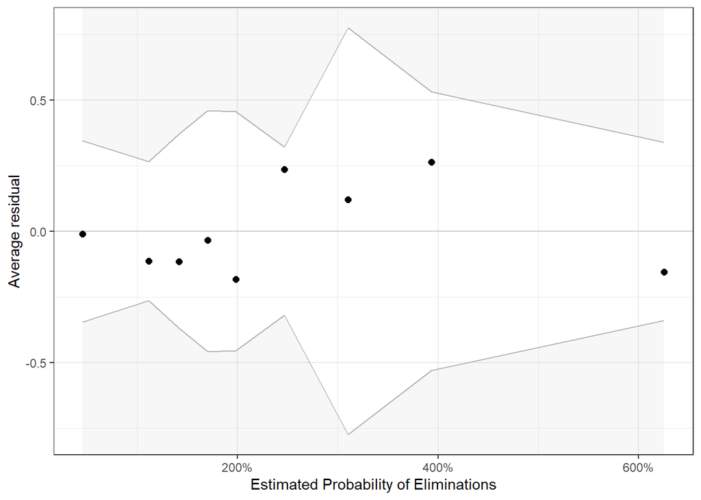

```
##
##  studentized Breusch-Pagan test
##
## data:  modelEli
## BP = 8.1855, df = 9, p-value = 0.5156
```

```
##
##  Shapiro-Wilk normality test
##
## data:  modelEli$residuals
## W = 0.958, p-value = 0.006513
```

A continuacion nos llamaba la antencion que en la base de datos aparecia una variable que permitiria explicar, o influir en el desempeño en el juego. Esta variable es el Estado Mental.

Se evidencia que el Estado Mental y su rendimiento no tiene mayores impactos. A su vez, el Estado Mental se diferenciaba por el momento del dia.

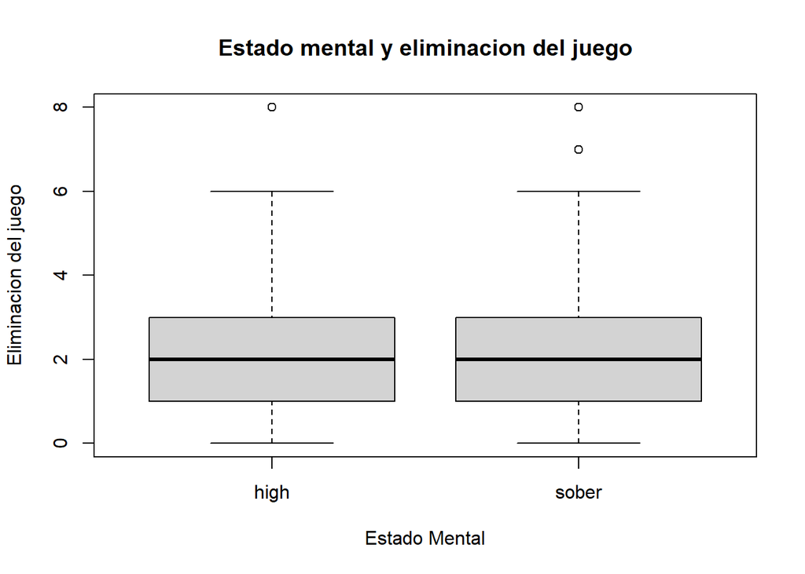

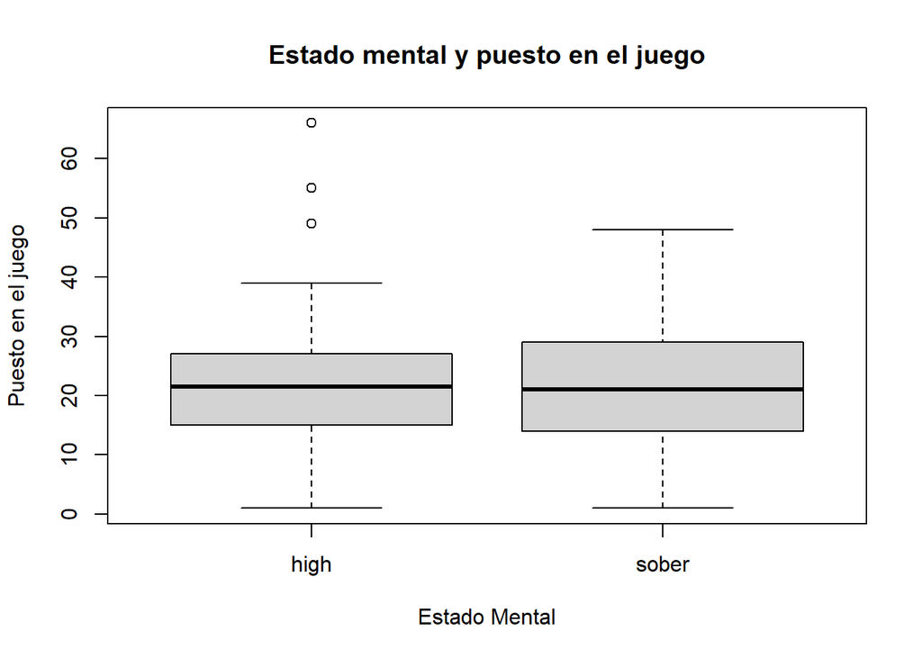

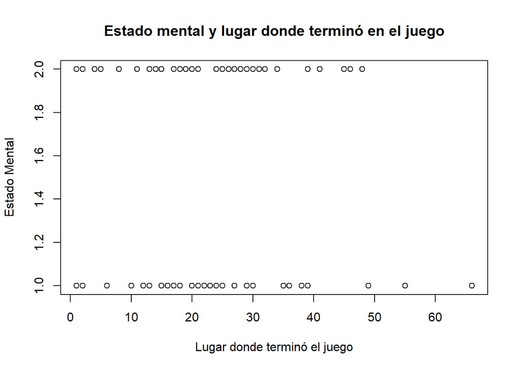

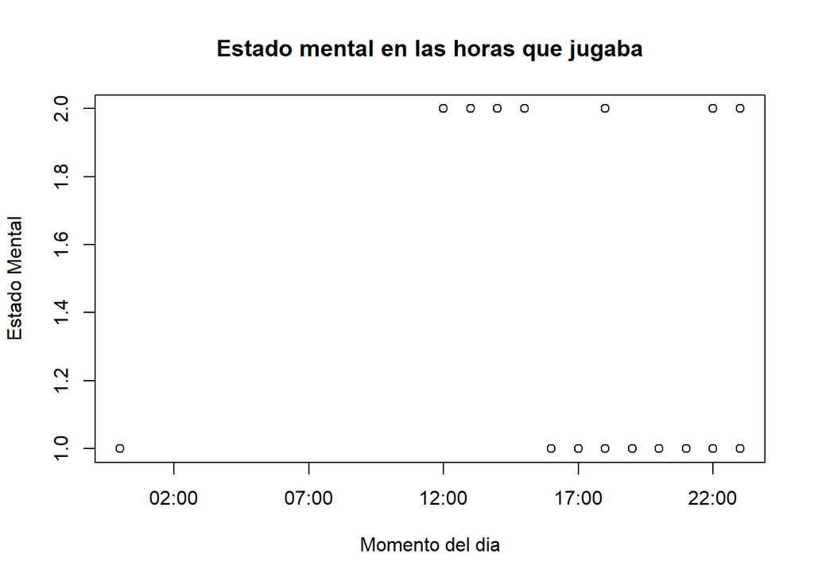